# Random variables, probabilities and distributions

2022-07-12

## Bulletin

- No lab next week
- Regression project due next Tuesday
- Exam 2 next Thursday
- Extra exam review session / office hours next week (time TBD)

## Today

By the end of today you will…

- be able to define and give examples of sample space, outcomes, events, probabilities, conditional, marginal, joint and independent probabilities, binomial distribution, normal distribution, sample, continuous and discrete random variables.
- practice computing probabilites, visualizing distributions and simulating samples from binomial and normal distributions

## Getting started

Download this application exercise by pasting the code below into your **console**

```
download.file("https://sta101.github.io/static/appex/ae8.Rmd",
destfile = "ae8.rmd")
```

## Load packages

```r
library(tidyverse)
library(knitr) # contains kable()
```

## Notes

### Sample space

The **sample space** is the set of all possible outcomes of an experiment.

#### Discrete examples

- Experiment 1: You flip a coin once. The sample space is $\{H, T\}$.

We separate each outcome by a comma and use brackets $\{ \}$ to denote a “set”.

- Experiment 2: You flip a coin twice. The sample space is $\{ HH, HT, TH, TT\}$
- Experiment 3: You roll a die once. The sample space is $\{ 1, 2, 3, 4, 5, 6\}$
- Experiment 4: You send out a survey asking participants whether they prefer cats or dogs. The sample space is $\{ \text{Cats}, \text{Dogs} \}$
- Experiment 5: A car manufacturer makes 100 vehicles. You count the number of recalls. The sample space is $\{0, 1, 2, 3, \ldots, 99, 100 \}$

#### Continuous examples

- Experiment 6: You observe the numeric grade you earn in a course. The sample space is $[0, 100]$

Here we write the lower bound and upper bound of the sample space and assume we can observe all values in-between. Brackets, $[$ $]$, are inclusive of the end values while parentheses, $($ $)$, are not.

- Experiment 7: You measure the tail length of American alligators The sample space is $(0, c ]$ feet where $c$ is the maximum tail length of an alligator, e.g. $c$ might be approximately 10.
- Experiment 8: You measure the geographic coordinates (longitude and latitude) of a COVID case. The sample space is $[-90, 90]$ for latitude and $[-180, 180 ]$ for longitude.

### Events

An **event** is a collection of 1 or more outcomes. Two events are said to be **disjoint** if they cannot occur at the same time.

#### Examples

- You roll a die once. Let *A* be the event that you roll an even number, i.e. *A* $= \{2, 4, 6 \}$. Let *B* be the event you roll a 1 or a 2, i.e. *B* $= \{1, 2 \}$. *A* and *B* are **not** disjoint.
- A car manufacturer makes 100 vehicles. You count the number of recalls. Let *C* be the event you see fewer than 10 recalls. *C* $= \{0, 1, 2, 3, \ldots, 8, 9 \}$
- You observe the numeric grade you earn in a course. Let *D* be the event you receive a letter grade of “A”. *D* $= [93, 100]$. Let *E* be the event that you earn a “B” or worse. *E* $= [0, 87)$. *D* and *E* **are disjoint** events because they cannot occur simultaneously.

### Probability

A **probability** is the long-run frequency of an *event*. In other words, the proportion of times we would see an event occur if we could repeat an experiment an infinite number of times. Probabilities take values between 0 and 1 inclusive.

If *A* and *B* are two disjoint events, then the probability of *A* or *B* occuring is equal to the probability of *A* plus the probability of *B*. More concisely, Pr(*A* or *B*) = Pr(*A*) + Pr(*B*).

#### More definitions

Let *A* and *B* be two events.

- Marginal probability: The probability an event occurs regardless of values of the other event
  - P(*A*)
  - Example: What’s the probability a student in STA101 is an airbender?
- Joint probability: The probability two or more events simultaneously occur
  - Example: What’s the probability a student is an airbender and favors dogs?
  - P(*A* and *B*)
- Conditional probability: The probability an event occurs given the other has occurred
  - P(*A*|*B*) or P(*B*|*A*)
  - Example: What is the probability a student is an airbender given they favor dogs?
- Independent events: Knowing one event has occurred does not lead to any change in the probability we assign to another event.
  - P(*A*| *B*) = P(*A*) or P(*B*|*A*) = P(*B*)
  - Example: P(Airbender | dogs) = P(Airbender)

Let’s try out some of these ideas with data from the in-class survey.

```r
class = read_csv("https://sta101.github.io/static/appex/data/sta101-su22.csv")
```

## Practice

#### Exercise 1

What is the probability a randomly selected STA101 student is a Earthbender?

```r
# code here
```

What is the probability a randomly selected STA101 student is a Waterbender given that they prefer cats?

```r
# code here
```

Let *A* be the event that a person prefers dogs and *B* be the event a person is an Airbender. Are events *A* and *B* independent?

```r
# code here
```

Let *C* be the event a person likes cats and *D* be the event a person is a Firebender. Are *C* and *D* disjoint?

```r
# code here
```

## Practical answers to simple questions in R

#### Example

You toss a fair coin 10 times. Let *A* be the event there is at least one head.

What is the probability of *A*?

`rbinom()` arguments:

- size is the number of trials, aka the number of coin flips in 1 experiment
- prob is the probability of a success
- n defines how many times to repeat the entire experiment

```r
N = 100
coin_flips = data.frame(num_heads = rbinom(n = N, size = 10, prob = 0.5))

coin_flips %>%
  filter(num_heads >=1) %>%
  nrow() / N
```

```
## [1] 1
```

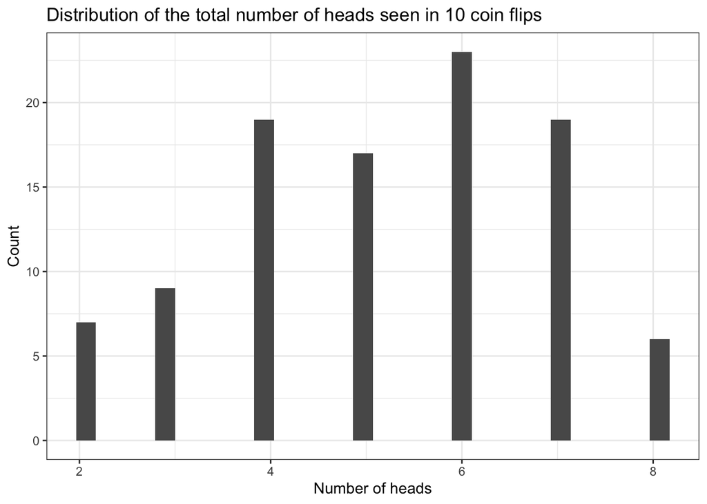

```r
coin_flips %>%
  ggplot(aes(x = num_heads)) +
  geom_histogram() +
  theme_bw() +
  labs(x = "Number of heads", y  = "Count", title = "Distribution of the total number of heads seen in 10 coin flips")
```

#### Example

How many people prefer dogs to cats? Make your tables pretty with `kable()`. Read `?kable` for more details

```r
class %>%
  count(pet) %>%
  kable(col.names = c("Pet", "Number"))
```

| Pet | Number |
| --- | --- |
| Cat | 3 |
| Dog | 17 |

`sample()` is a powerful function. 17/20 students in STA101 prefer dogs to cats. Let’s assume ask 10 more people if they prefer dogs to cats and assume that 17/20 is the true proportion of people that prefer dogs.

```r
set.seed(1) # ensure you and I will both get the same "random" result

outcomes = c("Dogs", "Cats")

sample(outcomes, size = 10, replace = TRUE, prob = c(0.85,0.15))
```

```
##  [1] "Dogs" "Dogs" "Dogs" "Cats" "Dogs" "Cats" "Cats" "Dogs" "Dogs" "Dogs"
```

Alternatively, we could have used `rbinom()`. When using a `rbinom()` we must define our outcomes “success” (1) and a “failure” (0). This is arbitrary and does not reflect the outcome itself being positive or negative. Let’s call “Dogs” a success and “Cats” a failure (1 and 0 respectively).

```r
set.seed(1)
# we survey 10 people 1 time
numberOfPeople = 10
numberOfSurveys = 1
probOfSuccess = 17 / 20
rbinom(n = numberOfPeople, size = numberOfSurveys, prob = probOfSuccess)
```

```
##  [1] 1 1 1 0 1 0 0 1 1 1
```

#### Example

You roll a six-sided die five times. Let *B* be the event that you roll exactly one “2”. What is the probability of *B*?

```r
outcomes = 1:6
one.roll = function() {
  roll = sample(outcomes, size = 1, replace = TRUE)
  return(roll)
}

five.rolls = function() {
  rolls = replicate(5, one.roll())
  return(sum(rolls == 2) == 1)
}

samples = replicate(10000, five.rolls())
mean(samples)
```

```
## [1] 0.4041
```

#### Exercise 2

Modify the code above to instead generate 1000 random samples of bender element, e.g. “Airbender”, “Waterbender”, etc. where each one is equally likely. Visualize the distribution using `geom_bar()`.

```r
# code here
```

## Random variables

You may not have realized it, but we’ve been talking about **random variables**. A **random variable** is a function that maps an observed outcome to a number.

For example, when you ask someone what pet they prefer, and map “Dog” to 1 and “Cat” to 0, you are defining a random variable!

Random variables have distributions…

## Distributions

### Binomial distribution

The **binomial distribution** models the number of success in a series of independent and identical binary trials and is defined by two parameters:

- $k$, the total number of trials,
- $p$, the probability of a success in an individual trial.

The sample space of a binomial random variable is $\{0, 1, \ldots, k \}$. In words, there could be up to $k$ success in an binomial experiment.

#### Exercise 3

Assume that the true proportion of people who prefer dogs is in fact 17 / 20.

Let’s perform a simulation. Go out and ask 100 people if they prefer cats or dogs using `rbinom()` (where 0 is cat and 1 is dog). This is called a **single sample** of 100 individuals. What proportion of people prefer dogs to cats in your new sample?

Now repeat this 10 times. What is the average number of people **in each sample**? Plot the distribution of the mean across all 10 samples.

Now ask 100 samples of 100 people the same question and plot the distribution of the mean.

Now ask 1000 samples of 100 people the same question and plot the distribution of the mean. What do you notice?

Note: you might need to play with `binwidth` argument of `geom_histogram()` for the best results.

```r
set.seed(714)
# code here
```

### Normal distribution

The **normal distribution**, also known as “Gaussian distribution” is a distribution of a continuous random variable. The sample space of a normal random variable is $\{- \infty, + \infty \}$ and is defined by two parameters: a mean $\mu$ and a standard deviation $\sigma$.

We can sample `N` times from a normal with mean `mu` and standard deviation `s` using `rnorm(n = N, mean = mu, sd = s)`.

Let’s visualize the normal function curve using the code below.

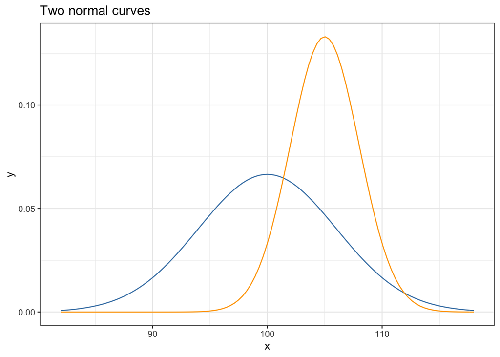

```r
mu1 = 100
s1 = 6

mu2 = 105
s2 = 3

ggplot(data = data.frame(x = c(mu1 - s1*3, mu1 + s1*3)), aes(x = x)) +
  stat_function(fun = dnorm, args = list(mean = mu1, sd = s1),
                color = "steelblue") +
  stat_function(fun = dnorm, args = list(mean = mu2, sd = s2),
                color = "orange") +
  theme_bw() +
  labs(title = "Two normal curves")
```

#### Exercise 4

Try setting `mu2` to 99 and `s2` to 4. What do you notice? Play with a few more settings and describe what the mean and standard deviation do to the shape of the curve.

#### Exercise 5

Paste the code of your histogram from exercise 3 below but change your geometry to `geom_histogram(aes(y = ..density..))`. This will rescale your histogram so that the area under the curve is 1. Next, use the `stat_function` code above as a template to superimpose a normal distribution on top of your histogram. Adjust the mean and standard deviation until you obtain a good looking fit. What do you notice?

```r
set.seed(714)
# code here
```